# CD4 T: Label and coordinate transfer (validation cohort)

Ramon Massoni-Badosa

2023-06-01

# 1 Introduction

Here, we will transfer the label and UMAP coordinates from the discovery cohort to the validation cohort. We will do it one compartment at a time (e.g. cd4), so we can validate that the transfer is robust

Specifically, we will follow these steps for every compartment:

# 2 Pre-processing

## 2.1 Load packages

```r
library(Seurat)
library(scCustomize)
library(tidyverse)
library(propr)
library(caret)
library(class)
library(harmony)
library(here)
library(glue)
library(DT)
library(pheatmap2)
```

## 2.2 Source functions

```r
source(here("scRNA-seq/bin/SLOcatoR_functions.R"))
source(here("scRNA-seq/bin/utils.R"))
source(here("scRNA-seq/bin/utils_figure2.R"))
source(here("scRNA-seq/bin/utils_final_clusters.R"))
color_palette <-  c("#1CFFCE", "#90AD1C", "#C075A6", "#85660D", "#5A5156", "#AA0DFE",
                    "#F8A19F", "#F7E1A0", "#1C8356", "#FEAF16", "#822E1C", "#C4451C",
                    "#1CBE4F", "#325A9B", "#F6222E", "#FE00FA", "#FBE426", "#16FF32",
                    "black",   "#3283FE", "#B00068", "#DEA0FD", "#B10DA1", "#E4E1E3",
                    "#90AD1C", "#FE00FA", "#85660D", "#3B00FB", "#822E1C", "coral2",
                    "#1CFFCE", "#1CBE4F", "#3283FE", "#FBE426", "#F7E1A0", "#325A9B",
                    "#2ED9FF", "#B5EFB5", "#5A5156", "#DEA0FD", "#FEAF16", "#683B79",
                    "#B10DA1", "#1C7F93", "#F8A19F", "dark orange", "#FEAF16", "#FBE426",
                    "Brown")
```

# 3 CD4

```r
# Read data, clean and include annotation
cd4 <- readRDS(here("scRNA-seq/results/R_objects/seurat_objects_revision/4.8-CD4_T_seurat_object_discovery_validation_cohorts.rds"))
```

First, let’s save the naive CD8 T-cells that have been missclassified in a different object:

```r
old_cd8 <- readRDS(here("scRNA-seq/results/R_objects/final_clusters/20220215/20220215_CD8_T_seurat_obj.rds"))
cd8_barcodes <- colnames(cd4)[colnames(cd4) %in% colnames(old_cd8)]
length(cd8_barcodes)
```

```
## [1] 4616
```

```r
cd4 <- FindNeighbors(cd4, dims = 1:25, reduction = "harmony")
cd4 <- FindClusters(cd4, resolution = 0.15)
```

[output not shown]

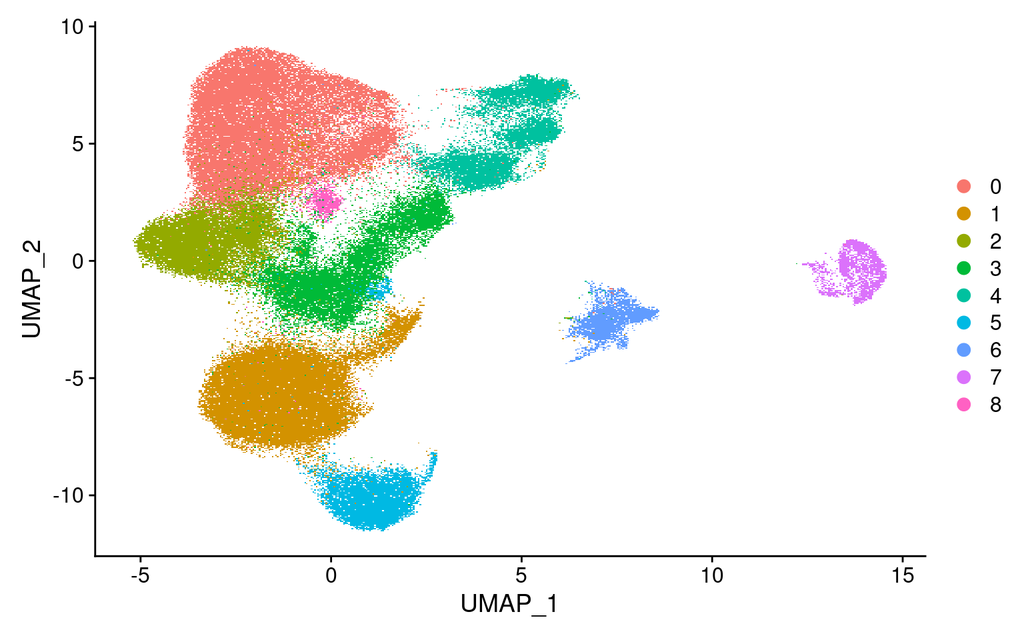

```r
DimPlot(cd4)
```

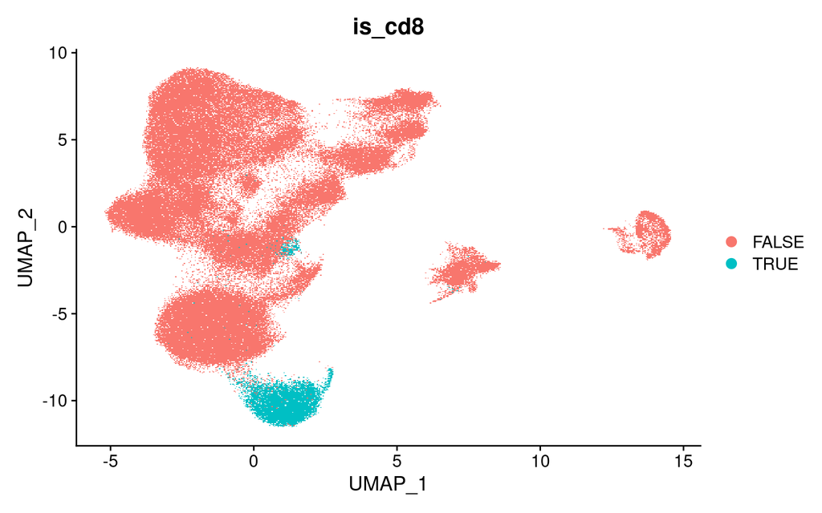

```r
cd8_barcodes <- c(cd8_barcodes, colnames(cd4)[cd4$seurat_clusters == "5" & cd4$cohort_type == "validation"])
cd4$is_cd8 <- ifelse(colnames(cd4) %in% cd8_barcodes, TRUE, FALSE)
DimPlot(cd4, group.by = "is_cd8")
```

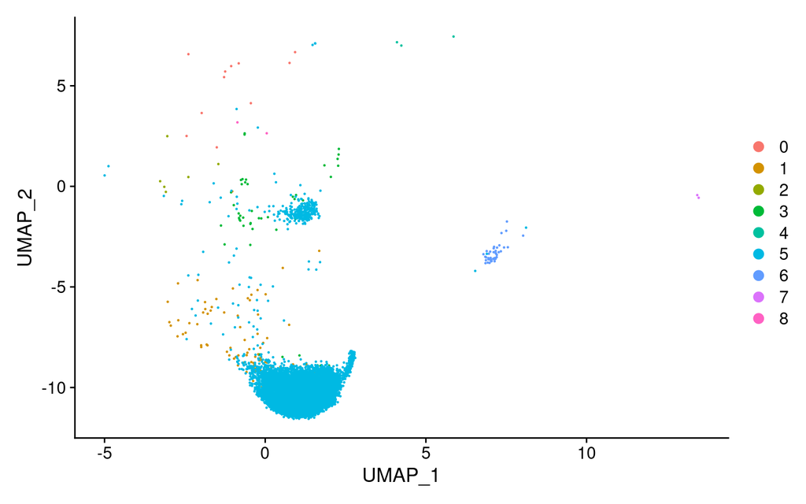

```r
cd8 <- cd4[, cd4$is_cd8]
cd4 <- cd4[, !cd4$is_cd8]
DimPlot(cd8)
```

```r
saveRDS(cd8, here("scRNA-seq/results/R_objects/seurat_objects_revision/naive_cd8_t_cells.rds"))
```

We proceed to update the annotation:

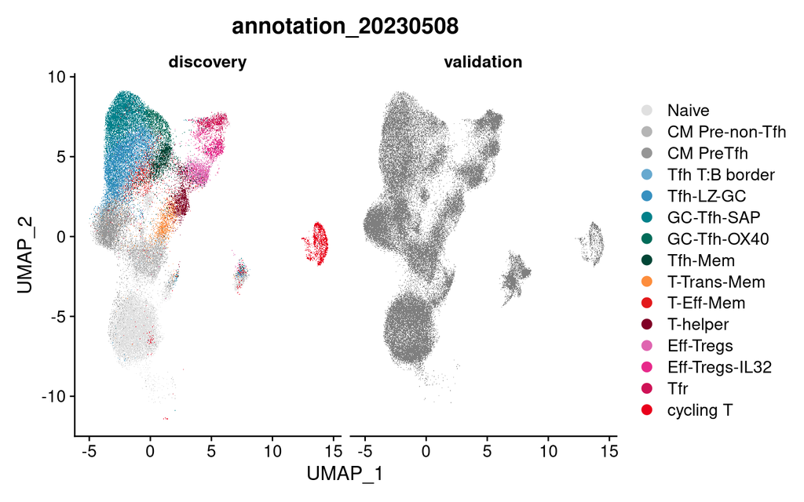

```r
cd4 <- updateAnnotation(cd4)
cd4$annotation_20230508 <- cd4$annotation_20220619
cd4$annotation_20230508[is.na(cd4$annotation_20230508)] <- "unannotated"
cd4$annotation_20230508 <- factor(
  cd4$annotation_20230508,
  levels = c(names(colors_20230508[["CD4"]]), "unannotated")
)
Idents(cd4) <- "annotation_20230508"
cd4$is_reference <- ifelse(
  cd4$cohort_type == "discovery",
  "reference",
  "query"
)
DimPlot(
  cd4,
  group.by = "annotation_20230508",
  split.by = "cohort_type",
  cols = colors_20230508[["CD4"]]
)
```

Let us explore if there are lingering doublets:

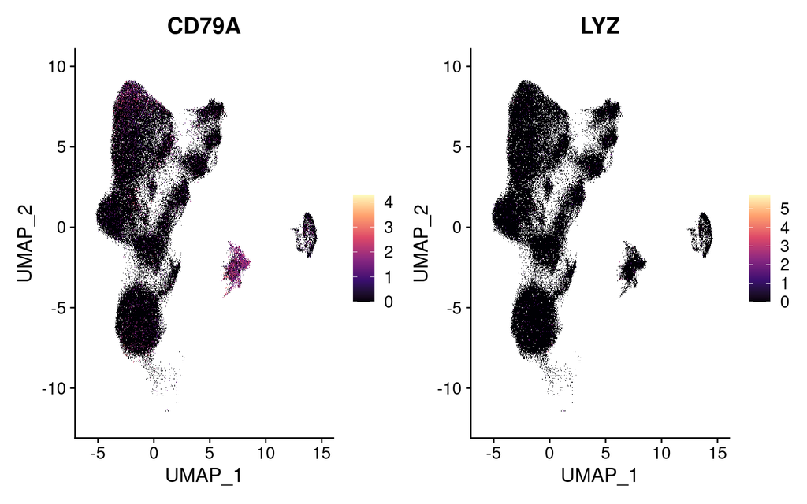

```r
Idents(cd4) <- "cohort_type"
FeaturePlot(cd4, c("CD79A", "LYZ")) &
  scale_color_viridis_c(option = "magma")
```

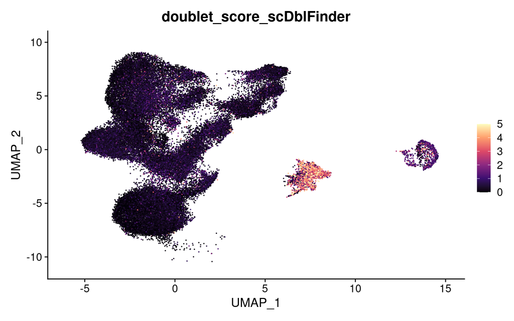

```r
FeaturePlot(cd4[, cd4$cohort_type == "validation"], "doublet_score_scDblFinder") &
  scale_color_viridis_c(option = "magma")
```

Indeed, one cluster is composed of doublets between B and CD4 T cells. Let us find it and remove it:

```r
cd4 <- FindNeighbors(cd4, dims = 1:25, reduction = "harmony")
cd4 <- FindClusters(cd4, resolution = 0.11)
```

[output not shown]

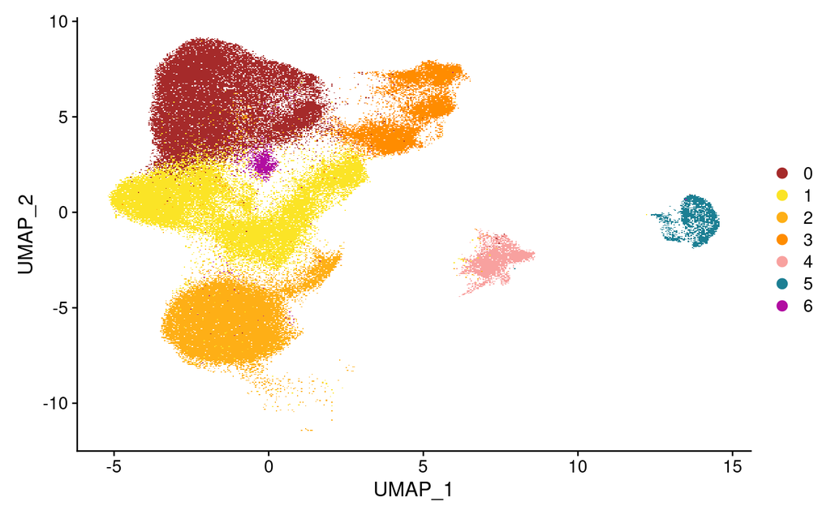

```r
DimPlot(cd4, cols = rev(color_palette))
```

```r
markers4 <- FindMarkers(cd4, ident.1 = "4", only.pos = TRUE, logfc.threshold = 0.75)
head(markers4, 30)
```

```
##          p_val avg_log2FC pct.1 pct.2 p_val_adj
## BANK1        0  1.0294162 0.701 0.033         0
## MEF2C        0  0.9240965 0.648 0.032         0
## CD74         0  1.0173399 0.946 0.547         0
## HLA-DRA      0  1.3282225 0.902 0.301         0
## HLA-DRB5     0  0.9042142 0.574 0.051         0
## HLA-DRB1     0  1.1598622 0.788 0.137         0
## HLA-DQA1     0  1.0717951 0.735 0.078         0
## HLA-DQB1     0  1.0727717 0.753 0.097         0
## HLA-DPA1     0  1.1667009 0.800 0.173         0
## HLA-DPB1     0  1.1863990 0.823 0.213         0
## MS4A1        0  1.2971079 0.848 0.120         0
## IGHM         0  0.9075096 0.668 0.190         0
## CD79A        0  0.9238177 0.722 0.124         0
```

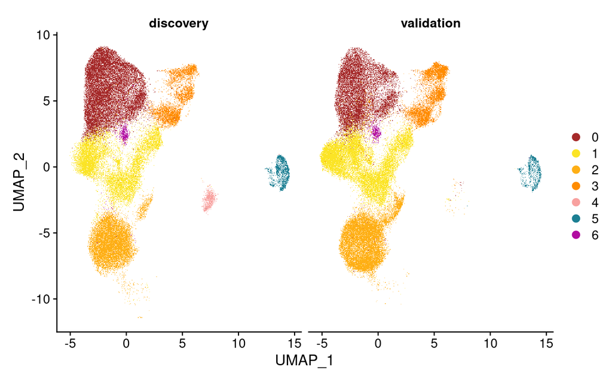

```r
cd4 <- cd4[, !(cd4$seurat_clusters == "4" & cd4$cohort_type == "validation")]
DimPlot(cd4, cols = rev(color_palette), split.by = "cohort_type")
```

Reintegrate:

```r
rm(old_cd8, cd8)
gc()
```

```
##             used   (Mb) gc trigger    (Mb)   max used    (Mb)
## Ncells   4214229  225.1    7344371   392.3    7344371   392.3
## Vcells 646766306 4934.5 2008538646 15324.0 1737021244 13252.5
```

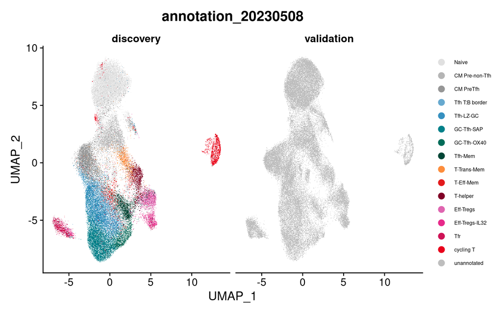

```r
cd4$type <- str_c(cd4$cohort_type, cd4$assay, sep = "_")
shared_hvg <- find_assay_specific_features(cd4, assay_var = "type")
cd4 <- integrate_assays(
  cd4,
  assay_var = "type",
  shared_hvg = shared_hvg
)
cd4 <- RunUMAP(cd4, dims = 1:25, reduction = "harmony")
DimPlot(
  cd4,
  group.by = "annotation_20230508",
  split.by = "cohort_type",
  cols = c(colors_20230508[["CD4"]], "unannotated" = "gray")
)  &
  theme(legend.text = element_text(size = 6))
```

Transfer label:

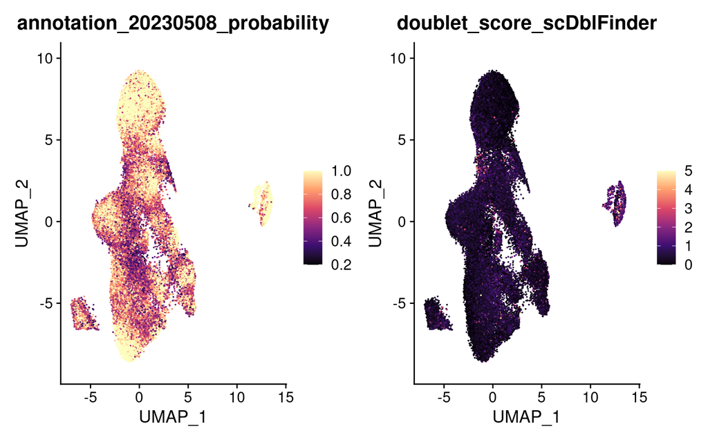

```r
# Split training and test sets
data_sets <- split_training_and_test_sets(
  cd4,
  split_var = "cohort_type",
  referece_label = "discovery",
  query_label = "validation",
  reduction = "harmony",
  n_dims = 25
)


# Transfer label
annotation_query_df <- transfer_label(
  seurat_obj = cd4,
  training_set = data_sets$training_set,
  test_set = data_sets$test_set,
  k = 20,
  response_var = "annotation_20230508"
)

# Include annotation and UMAP coords in Seurat object
cd4$annotation_20230508[annotation_query_df$query_cells] <- annotation_query_df$annotation
Idents(cd4) <- "annotation_20230508"
cd4$annotation_20230508_probability <- NA
cd4$annotation_20230508_probability[annotation_query_df$query_cells] <- annotation_query_df$annotation_prob
p1 <- FeaturePlot(
  cd4[, annotation_query_df$query_cells],
  "annotation_20230508_probability"
) + scale_color_viridis_c(option = "magma")
p2 <- FeaturePlot(
  cd4[, annotation_query_df$query_cells],
  "doublet_score_scDblFinder"
) + scale_color_viridis_c(option = "magma")
p1 | p2
```

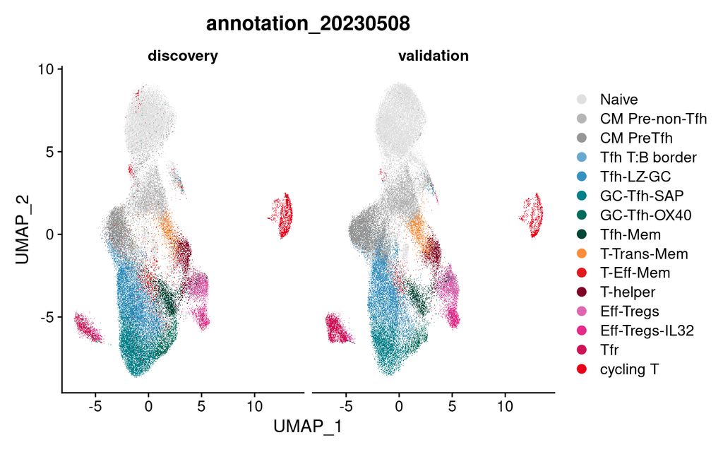

```r
DimPlot(
  cd4,
  group.by = "annotation_20230508",
  split.by = "cohort_type",
  cols = colors_20230508[["CD4"]]
)
```

```r
table(cd4$annotation_20230508_probability)
```

[output not shown]

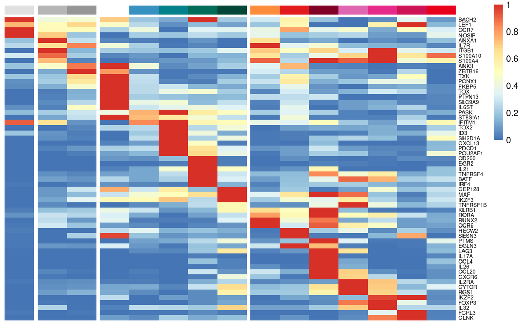

```r
goi_rna <- unlist(goi_rna)
names(goi_rna) <- NULL
avgexpr_mat <- AverageExpression(
  cd4[, cd4$cohort_type == "validation"],
  features = goi_rna,
  assays = "RNA",
  return.seurat = FALSE,
  group.by = "annotation_20230508",
  slot = "data"
)$RNA


# Define annotation column
cell_types <- levels(cd4$annotation_20230508)
mycolors <- list(cell_type = c(colors_20230508$CD4))
annotation_col <- data.frame(cell_type = cell_types)
rownames(annotation_col) <- cell_types


# Scale per row between 0 and 1
input_mat <- t(apply(avgexpr_mat, 1, function(x) (x - min(x)) / diff(range(x))))


# Plot heatmap
pheatmap2(
  input_mat,
  annotation_col = annotation_col,
  annotation_colors = mycolors,
  annotation_names_col = FALSE,
  annotation_legend = FALSE,
  show_rownames = TRUE,
  show_colnames = FALSE,
  border_color = NA,
  cluster_rows = FALSE,
  cluster_cols = FALSE,
  gaps_col = c(1, 3, 8),
  fontsize_row = 6
)
```

# 4 Save

```r
saveRDS(cd4, here("scRNA-seq/results/R_objects/seurat_objects_revision/5.8-CD4_seurat_object_discovery_validation_cohorts_annotation.rds"))
```